# Geographic Trends in Federal Spending and Measures of Well-Being

March 12, 2020

## Our Question: What are the relationships between states and regions with regard to pregnancy health, income inequality, and access to justice across the US and how do these outcomes relate to federal spending?

## Indices Explored:

- **Gini Index** - Measures wealth inequality on a scale from 0 (complete equality) to 1 (complete inequality) as tabulated by the Census Bureau using the American Communities Survey, 2010.
- **Pregnancy Health** - To assess this, we use five measures selected by United Health Foundation from the Centers for Disease Control and Prevention (CDC) and Guttmacher Institute to calculate a composite score for each state.
- **The Justice Index** - Scores and ranks ability to protect rights in a state justice system by assessing whether a person can afford a lawyer, has language access, and can navigate the legal system with physical and/or mental disability.
- **Federal Dependency** - A comparison of the amount of federal tax revenue generated by each state, versus the amount that state receives from the federal government at the individual and statewide levels.

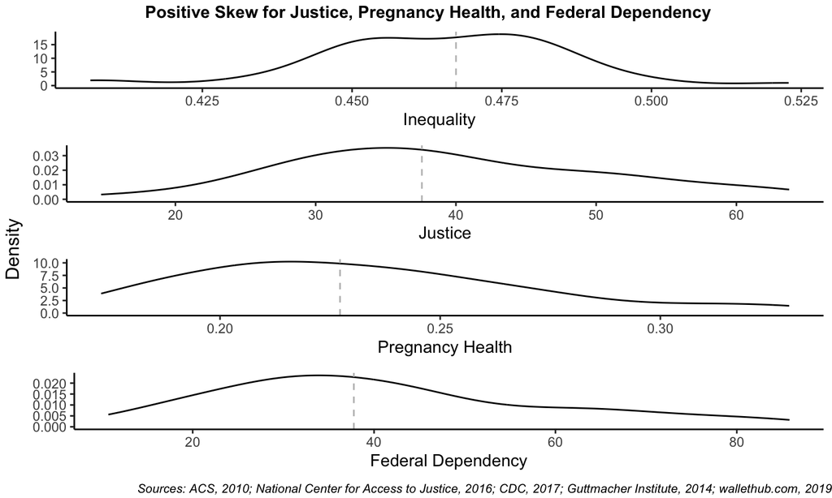

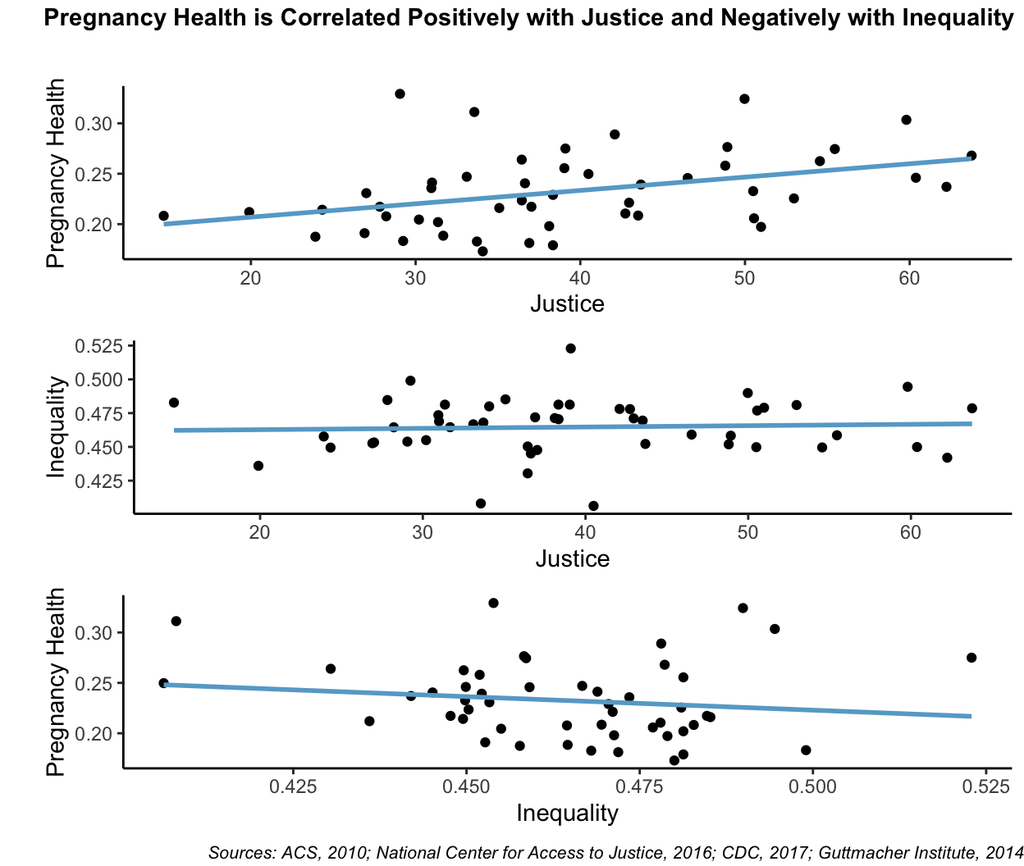

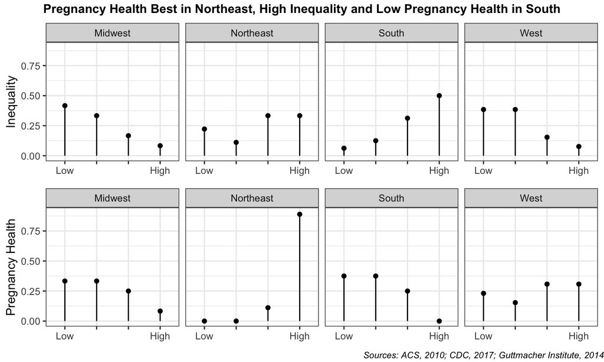

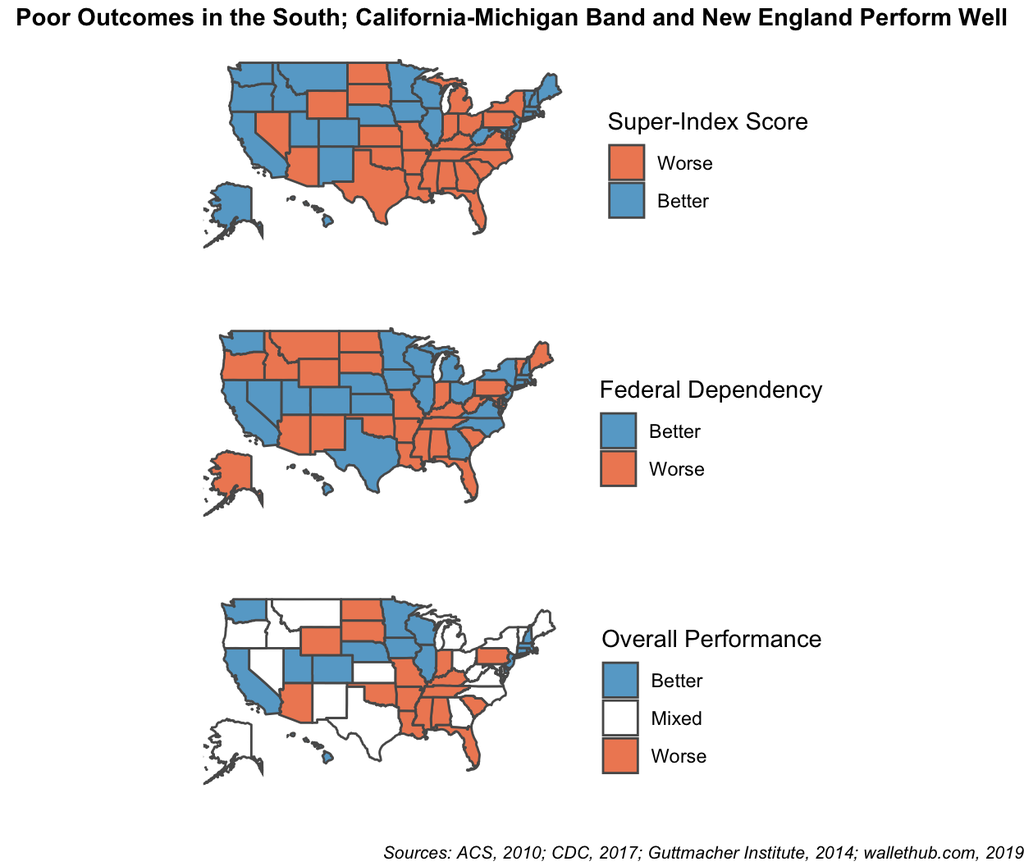

## Conclusions:

At a **regional level**, the Midwest and the West have mixed outcomes. The Northeast has higher inequality but the best pregnancy health, and the South stands out as a region with poorer social outcomes.

## A Note:

Our findings of worse outcomes in the South cannot be considered outside the context of US history. The making of American capitalism and prosperity was based largely on extracting wealth from slave labor in the South through a system of violence and oppression. Slavery enriched the US financial system, was a key driver of national economic growth, and fueled the industrial revolution in the North. Thus, as we compare between regions and states, we acknowledge that these maps tell a deeper story about the legacy of slavery and our racially structured economy and society. At large, the US has yet to transform its institutions in order to provide all Americans with equal access to health care, justice, and other measures of social well-being.